# Climate Vulnerability Indicators for Salmon: Methods and Results (draft)

Cory Lagasse, Josie Iacarella, Colin Bailey, Michael Arbeider

03 November 2025

Climate change is having profound effects on salmon populations in BC, contributing to declines of many stocks while introducing greater variability and uncertainty into assessments and planning (Macdonald and Grant 2023). A better understanding of the effects of climate change on salmon and their ecosystems can enable more realistic and effective long-term planning, and contextualize risks and benefits surrounding resource management decisions and mitigation actions.

This report presents a data-informed, indicator-based approach for evaluating climate change vulnerability of Pacific salmon conservation units (CUs). The framework draws upon recently developed models of future climate conditions (Peña and Fine 2024; Weller, Moore, and Iacarella 2024), cumulative habitat stressors (CSAS 2024a; Murray et al. 2024), population status assessments (CSAS 2024b), and life history timing (Wilson and Peacock 2025) to characterize relative climate vulnerability for 50 CUs throughout the Fraser River watershed.

Results presented in this report are preliminary and subject to change as the framework is further developed. Please do not distribute further without the authors’ permission.

# Methods Overview

Table 1 - Vulnerability Indicators

| abbrev | type | stat | std_fun | name |
| --- | --- | --- | --- | --- |
| favchange | fwR | mean | linear_std | ENM Change in Favourability |
| CT | fwR | mean | linear_std | Cumulative threats to freshwater habitat |
| tw8rate | fwR | mean | linear_std | Rate of change in August Temperature |
| tw8proj | fwR | mean | exponential_std | Projected August Temperature |
| lowQpdelta | fwR | mean | decay_std | Proportional change in August flow (stream model) |
| st8pdelta | fwR | mean | decay_std | Proportional change in August flow (station model) |
| highQpdelta | fwR | mean | exponential_std | Proportional change in Nov-Jan flow (stream model) |
| fwres | fwR | value | step_std | Freshwater residency time |
| migrT | migr | mean | exponential_std | Projected temperature during upstream migration |
| migrQ | migr | pdelta | decay_std | Proportional change in discharge during upstream migration |
| migrA21 | migr | mean | exponential_std | Average proportion of path above 21 degrees during upstream migration |
| migrdist | migr | value | linear_std | Length of upstream migration |
| SSTproj | mar | mean | exponential_std | Projected nearshore SST during ocean entry |
| SSTrate | mar | mean | linear_std | Rate of change in nearshore SST |
| CImpact | mar | mean | linear_std | Cumulative impacts to marine nearshore habitat |
| CUstatus | dem | category | cat_std | WSP status |
| CUnmat | dem | value | decay_std | Number of mature individuals |

**Indicator Standardization**  
All indicators are standardized using response functions to translate raw values to a scale from 0 to 1, where 0 represents lowest risk and 1 is the highest risk relative to other CUs. Standardization facilitates easier interpretation and comparison of indicators, and allows the representation of risk based on stressor-response relationships and thresholds. A linear function or exponential function was used for most indicators, with the lowest and highest values scaled to the 95th percentile of minimum and maximum CU values using ensemble means across GCMs.

**Estimating Overall Vulnerability**

To evaluate vulnerability across indicators, standardized values are combined within and across each category using additive and multiplicative approaches. Various methods are used in CCVAs and risk assessments for determining overall risk, such as additive or multiplicative scores, scaling between 0 and 1 (Boyce 2024; CSAS 2024a), threshold approaches (Fisheries and Oceans Canada 2019), and logic models (Crozier et al. 2019). For the preliminary outputs in this report, a combination of multiplicative and additive approaches are used. Further approaches for summarizing overall vulnerability and sensitivity to the selected method will be explored.

**Emissions scenarios and time period**  
CCVAs can assess vulnerability for a particular time period or multiple time periods, as well as different emissions scenarios depending upon assessment objectives. Indicators are based primarily on the CMIP5 suite of global climate models and results are presented for the representative concentration pathway (RCP) 4.5, representing moderate emission reductions compared to business as usual. Alternative results under RCP 8.5, representing higher climate forcing from emissions, are also shown where available. Results are currently presented for the mid-century period (2040-2060), but will also be compared to the end-of-century period (2080-2100) to examine the sensitivity of vulnerability indicator values over time.

# Overall Vulnerability

### Standardized indicator values

The following plots show standardized values of indicators across all conservation units. The values are standardized to a 0-1 scale, where 0 is the lowest value and 1 is the highest value for each indicator for each projected time period and emissions scenario.

#### 45

##### Spawning & Rearing exposure indicators

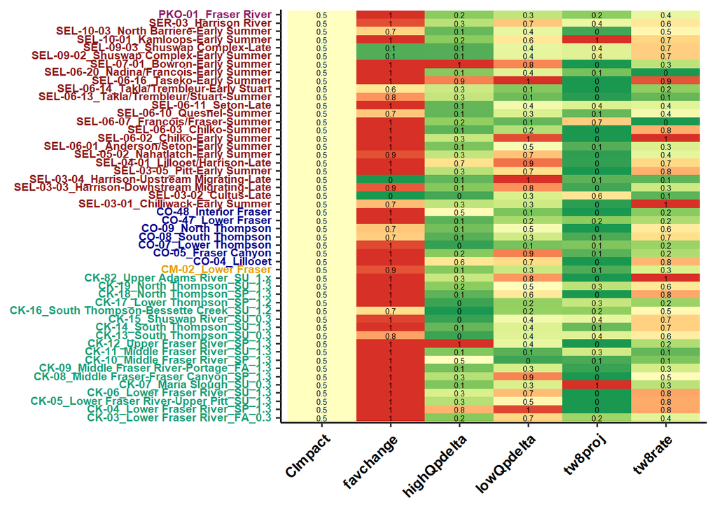

##### Upstream migration indicators

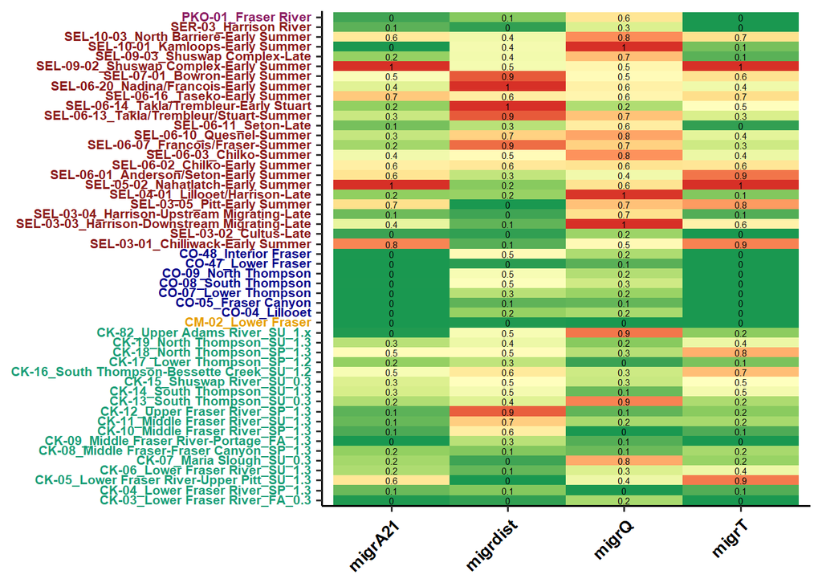

##### Demographic and marine indicators

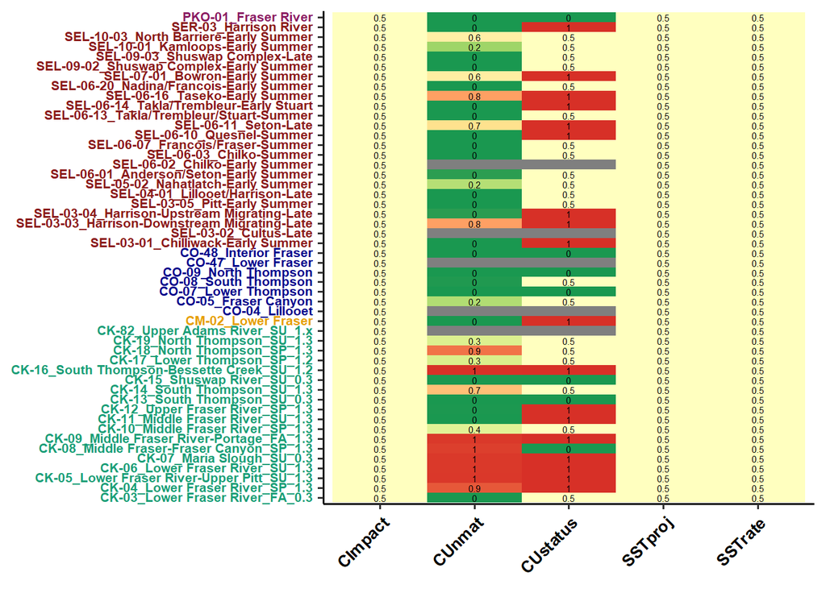

#### 85

##### Spawning & Rearing exposure indicators

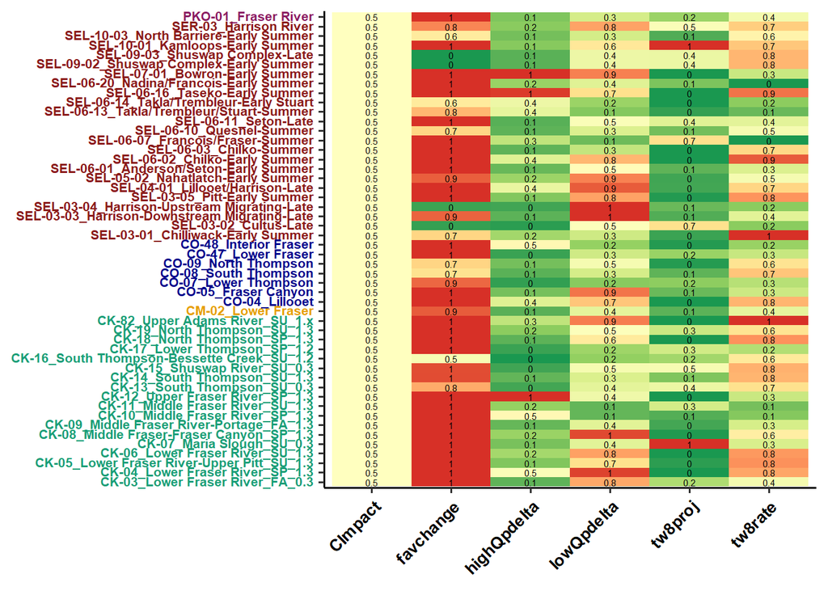

##### Upstream migration indicators

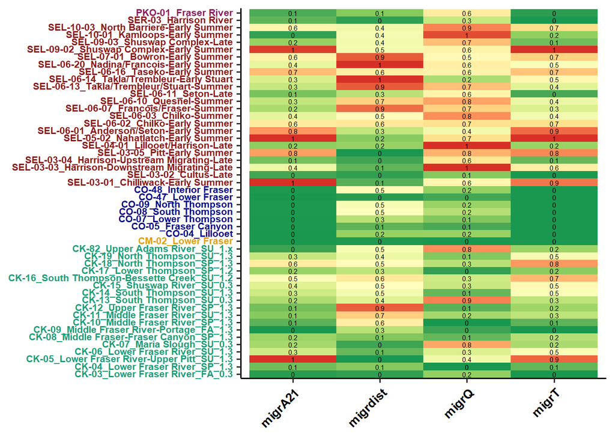

##### Demographic and marine indicators

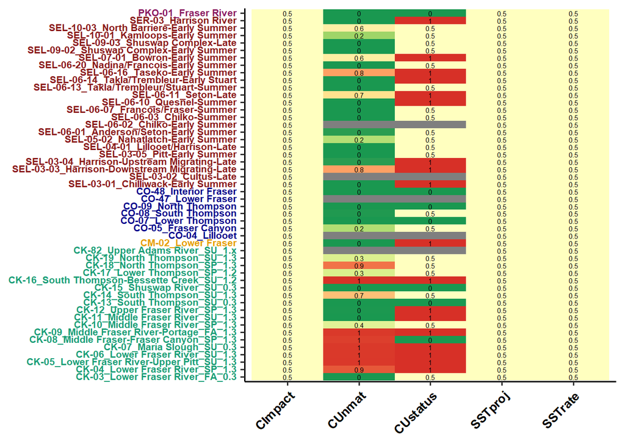

### Combined indicator scores

Overall climate vulnerability can be measured as the sum or average of the standardized scores for each indicator. The following plots show total scores and ranks across most indicators. Three methods are used for calculating total scores and ranks:  
addall - sum of all standardized indicator values  
avgall - average of all standardized indicator values  
sumavgs - sum of the average score for each life stage/type (freshwater spawning & rearing, upstream migration, demographic, and marine).

#### 45

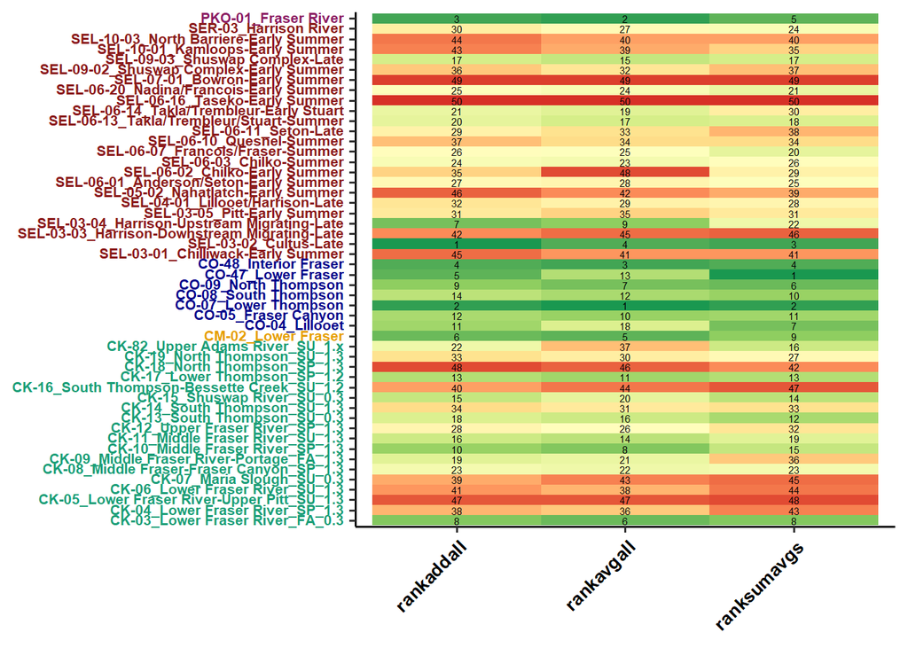

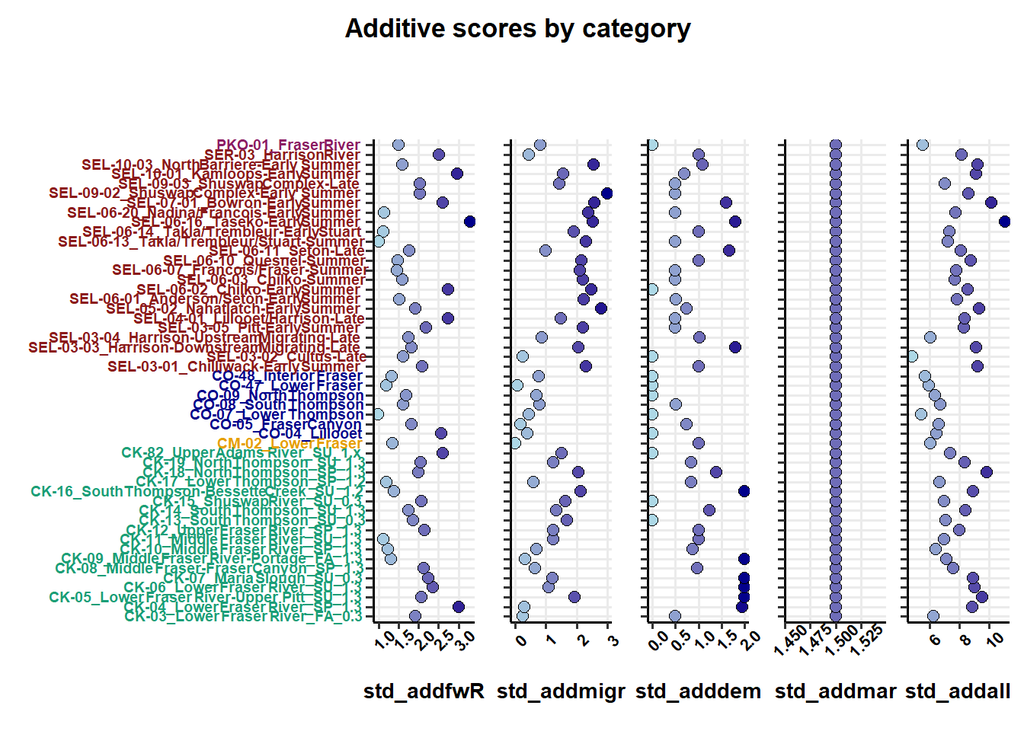

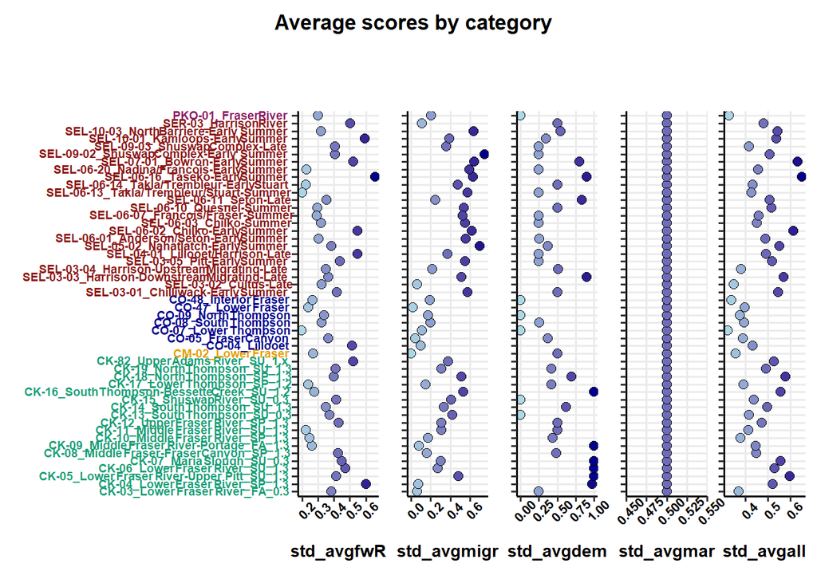

#### 85

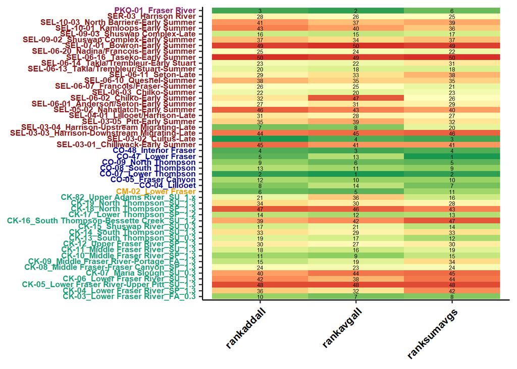

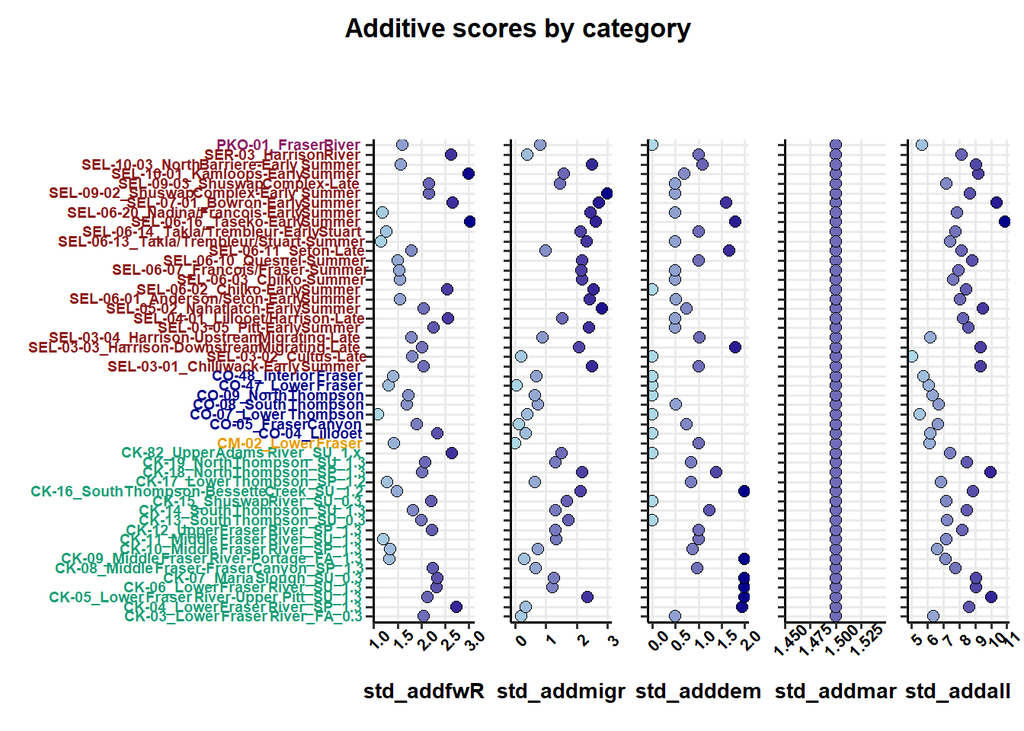

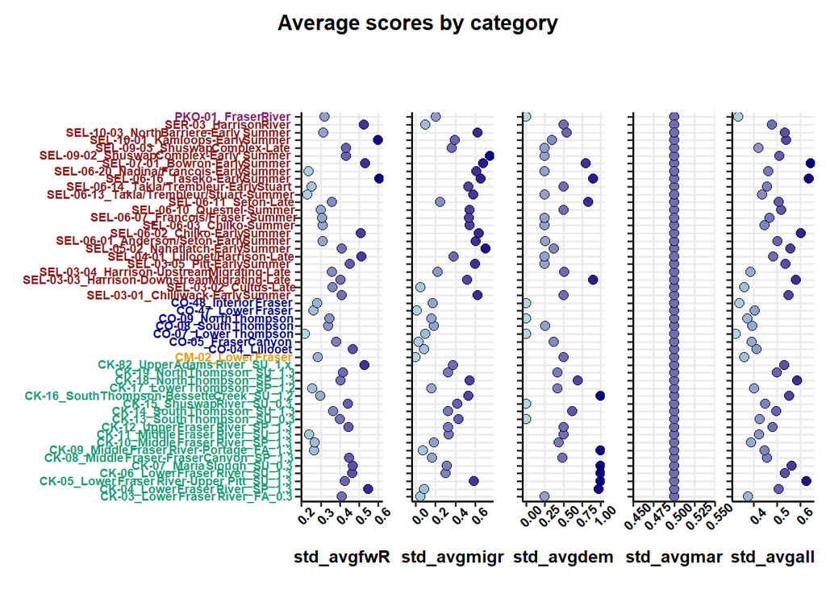

### Correlation of indicators

One test for the utility of an indicator is the correlation with other indicator values. The plot below shows correlation of raw indicator values, where higher correlation among indicators indicates potential overlap in the vulnerability mechanism or information being evaluated.

#### 45

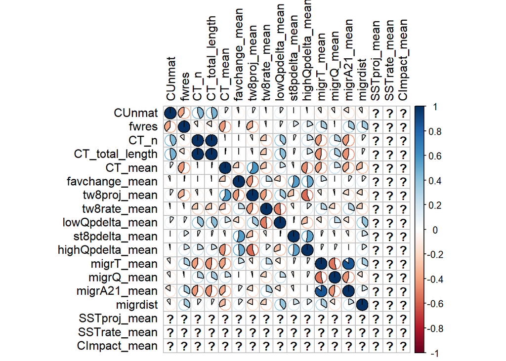

#### 85

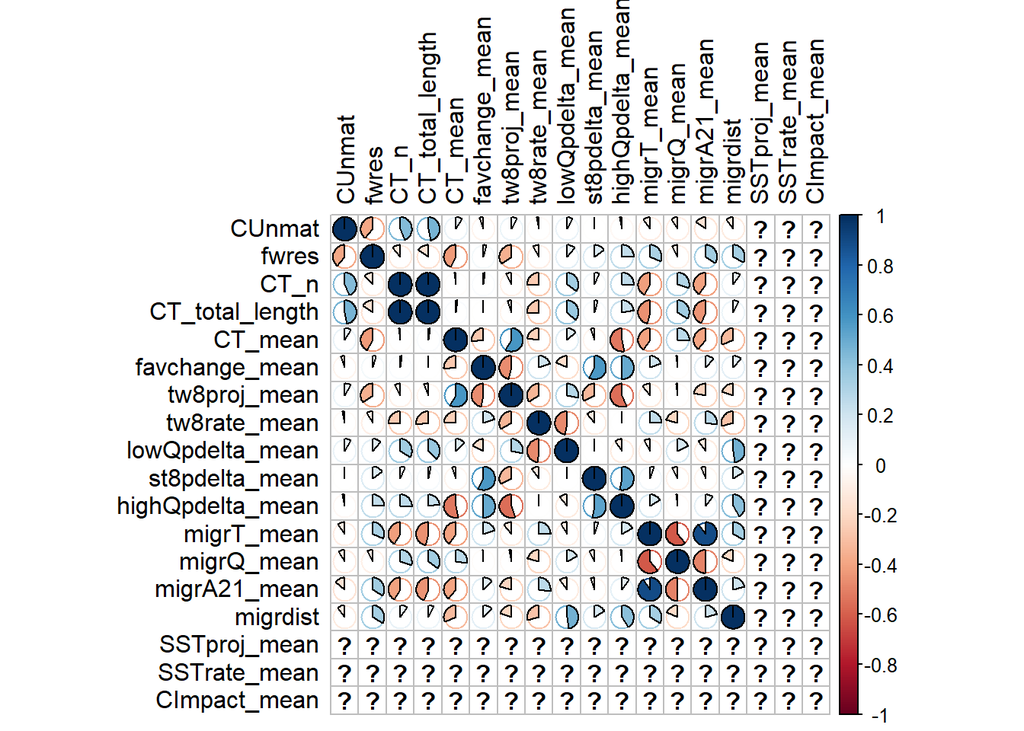

# Freshwater spawning to rearing

### Data Sources

**BCFishPass** - Freshwater fish habitat accessibility model used to subset accessible streams. [https://smnorris.github.io/bcfishpass/index.html]  
**CU boundaries** - spatial boundaries for CUs based on Freshwater Adaptive Zones. Taken from PSF data library [https://data.salmonwatersheds.ca/result?datasetid=104] **Cumulative Threats** - Cumulative threats to anadromous salmon stream habitat in the Fraser Basin [https://www.dfo-mpo.gc.ca/csas-sccs/Publications/SAR-AS/2024/2024_041-eng.pdf]  
**Thermalscapes Stream Temperatures** - Statistically downscaled projections of August stream temperature developed across British Columbia [https://datadryad.org/dataset/doi:10.5061/dryad.bzkh189fk]

**August flow projections at gauge stations** - Preliminary model outputs of statistically downscaled flow projections for gauge stations in British Columbia. Developed by Sacha Ruzzante et al.

**Environmental Niche Models** - Models of current and future habitat favourability for British Columbia and the Western US [https://cdnsciencepub.com/doi/10.1139/cjfas-2023-0096]

**PCIC Variable Infiltration Capacity With Glaciers (VIC-GL) gridded model** - Dynamically downscaled projections of stream temperature and flow from 1980 to 2099 for gauged watersheds within British Columbia [https://pacificclimate.org/analysis-tools/salmon-climate-impacts-portal]

**PSF CU-Specific Life History Timing** - timing of life history events for determining freshwater residency time [https://datadryad.org/dataset/doi:10.5061/dryad.wm37pvmwx]

### Spatial analysis methods

Vulnerability indicators for freshwater spawning and rearing life stages represent environmental change to streams, as well as cumulative threats to stream habitats and freshwater residency times. The British Columbia Freshwater Atlas was used as the stream network with spatial delineation to Pacific salmon conservation units based upon conservation unit boundaries. The stream network was limited to accessible streams with channel width and gradients that meet criteria for intrinsic habitat potential for each Pacific salmon species using the [BC Fishpass accessibility model](https://smnorris.github.io/bcfishpass/02_model_access.html) and [habitat model](https://smnorris.github.io/bcfishpass/03_model_habitat_linear.html). For sockeye salmon, the habitat model also includes criteria for proximity to lakes. This filtering process removed smaller and inaccessible streams while retaining all stream segments with observed occurrences and modelled habitat potential.

Environmental change indicators included projected August stream temperatures, rate of change in August stream temperature, percent change in August flows, percent change in flows from November to January, and change in environmental niche model habitat suitability. Each indicator was calculated as the mean value across all stream segments assigned to the conservation unit, weighted by stream segment length. Temperature indicators (projected and rate of change) were based on a statistical downscaling approach fitted to streams throughout British Columbia (Weller et al. 2024). Hydrologic indicators were based on the Pacific Climate Impacts Consortium gridded hydrological model that was further downscaled to the Fraser basin stream network (CSAS 2024). For the indicator of percent change in August flows, an alternative set of projections using a statistical downscaling approach fitted to hydrometric stations in BC (Ruzzante in prep) was also applied to compare variation in responses (to be further described in an appendix).

Variation in environmental change indicators for each CU was summarized across global climate model projections and spatial dimensions using 80% quantile ranges. Spatial variation quantiles were weighted by stream length and characterized the range in responses for accessible streams with intrinsic habitat potential using the ensemble mean of climate model projections. Global climate model quantiles represented the variation of the weighted mean for streams within the CU boundary across all included global climate models (generally 6).

The freshwater spawning/rearing indicators are:

Spawning and rearing indicators

| abbrev | type | stat | std_fun | name |
| --- | --- | --- | --- | --- |
| favchange | fwR | mean | linear_std | ENM Change in Favourability |
| CT | fwR | mean | linear_std | Cumulative threats to freshwater habitat |
| tw8rate | fwR | mean | linear_std | Rate of change in August Temperature |
| tw8proj | fwR | mean | exponential_std | Projected August Temperature |
| lowQpdelta | fwR | mean | decay_std | Proportional change in August flow (stream model) |
| st8pdelta | fwR | mean | decay_std | Proportional change in August flow (station model) |
| highQpdelta | fwR | mean | exponential_std | Proportional change in Nov-Jan flow (stream model) |
| fwres | fwR | value | step_std | Freshwater residency time |

### Projected August temperature (Tw8Proj)

#### 45

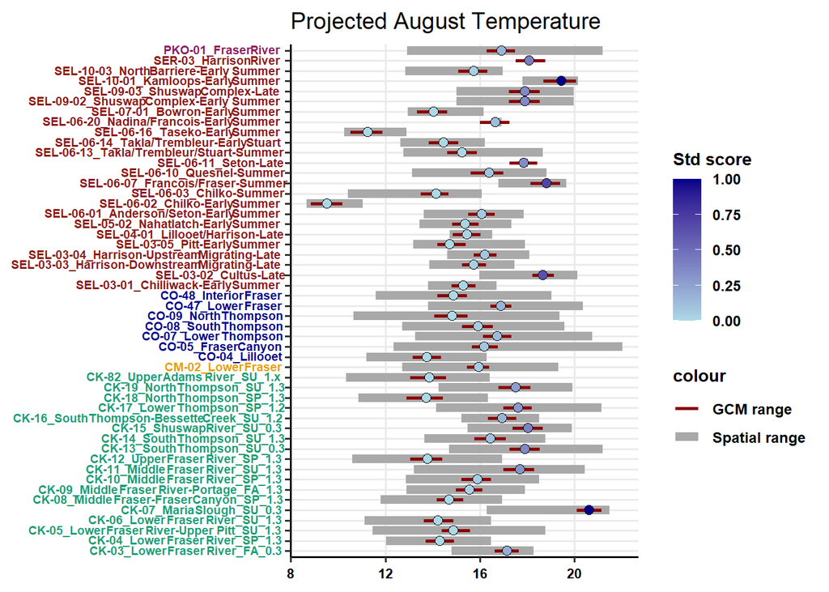

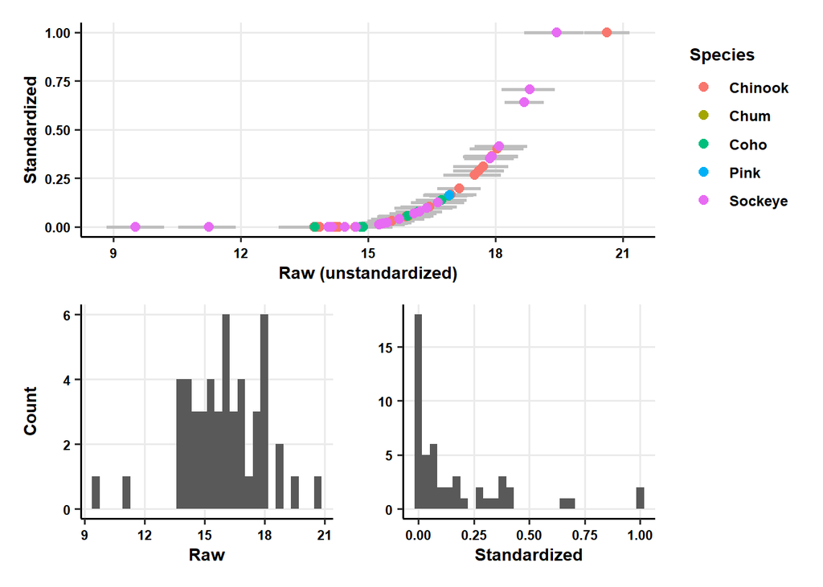

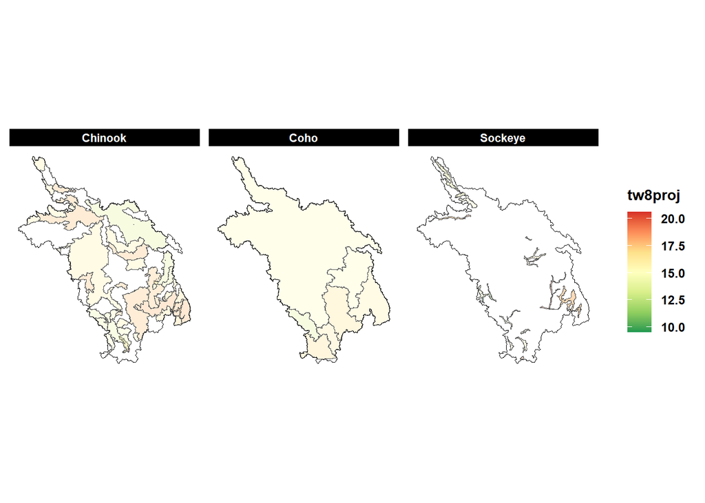

#### 85

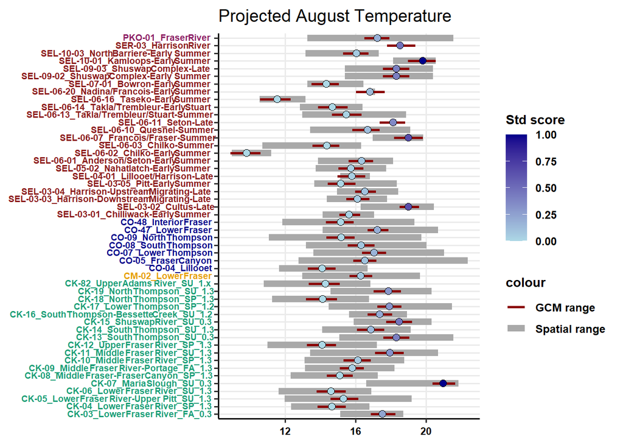

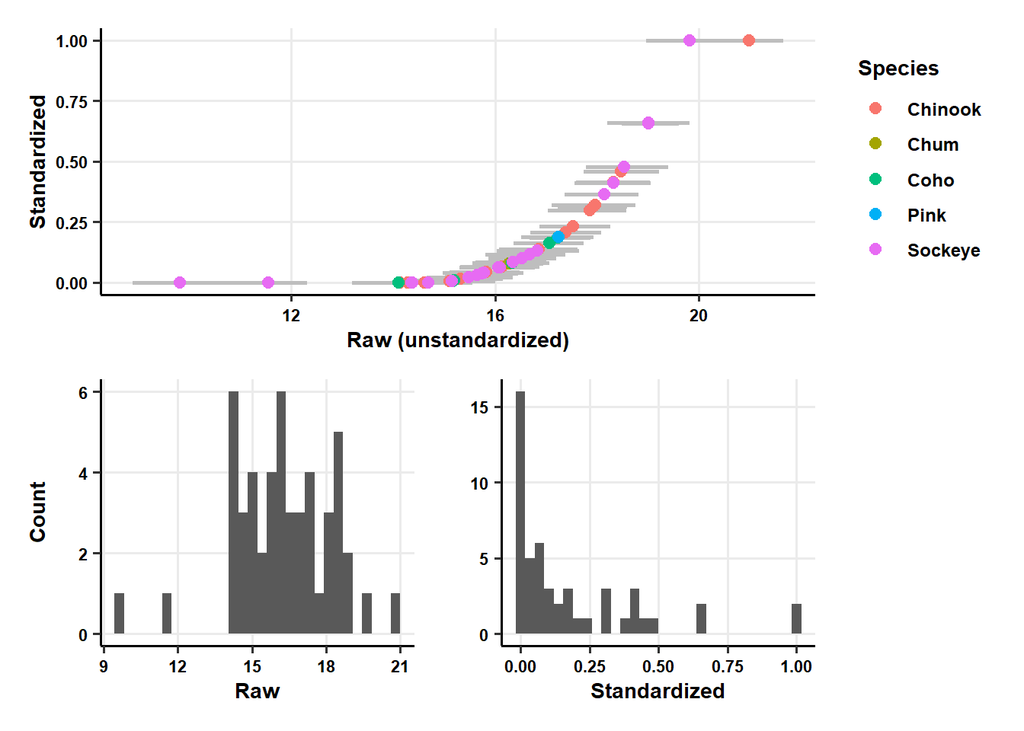

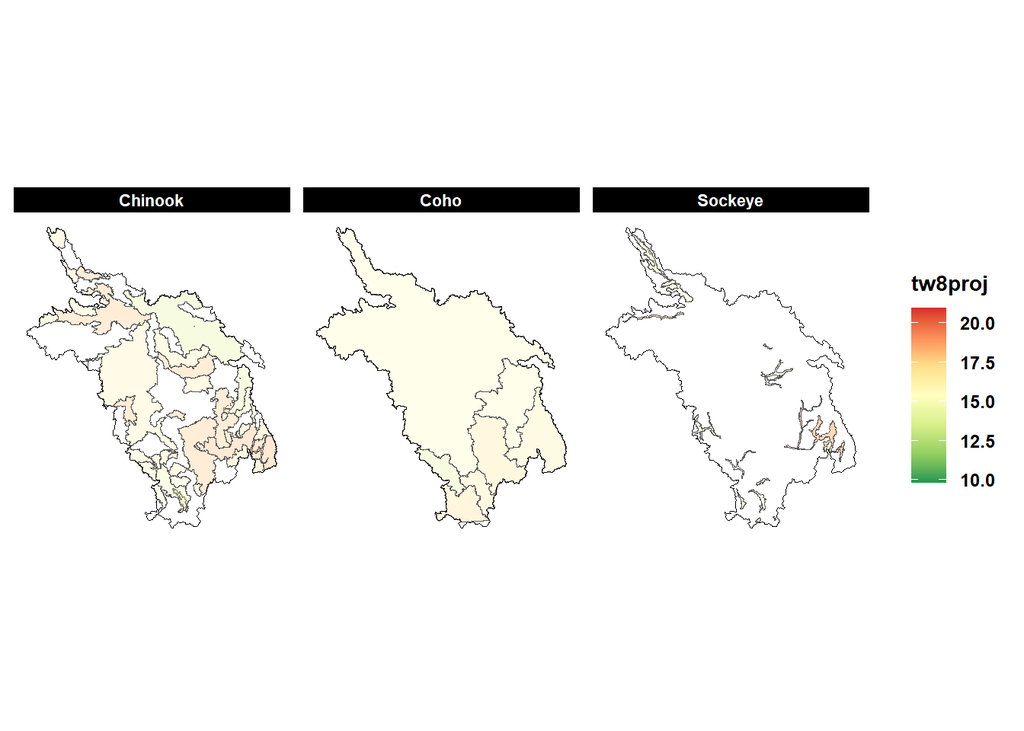

### Rate of change in August temperature

#### 45

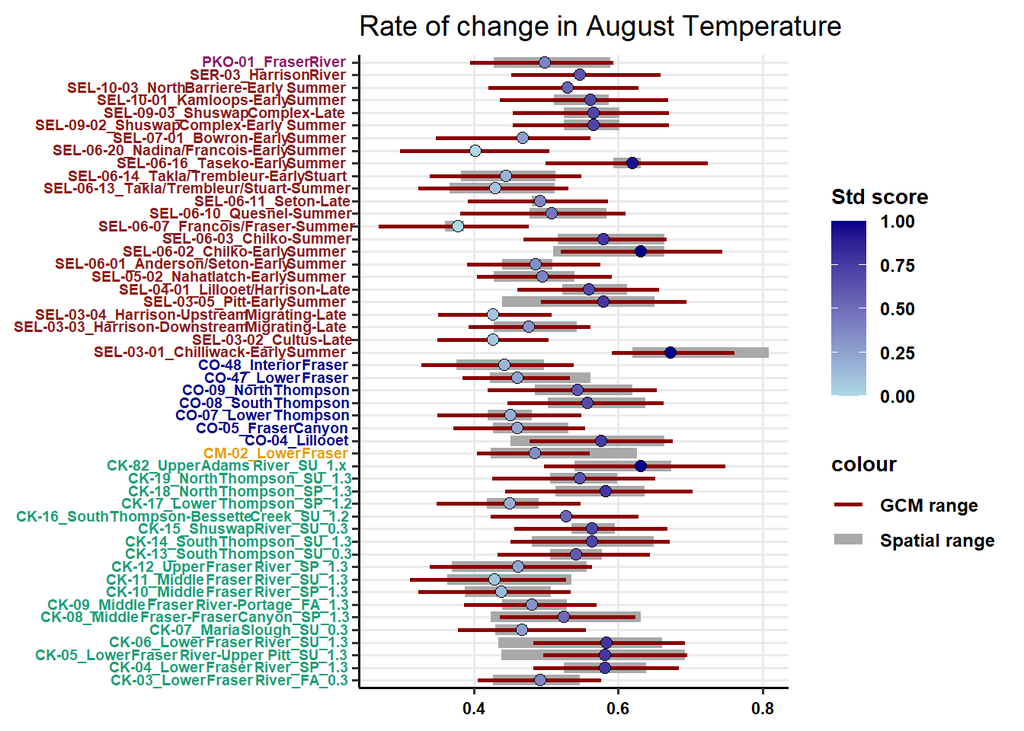

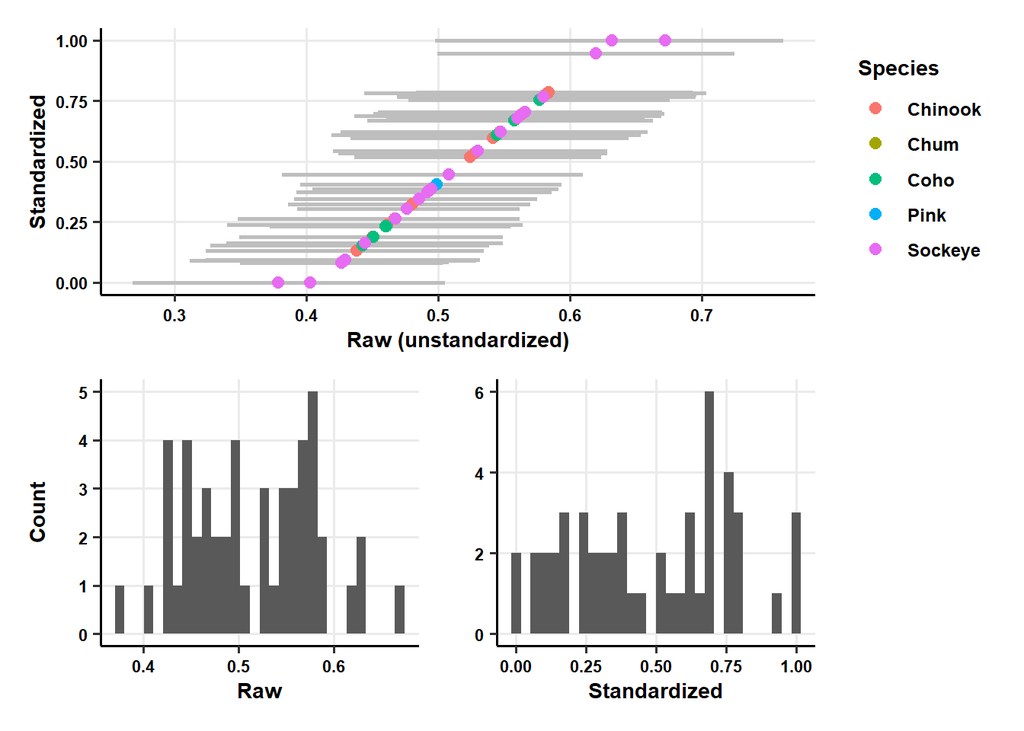

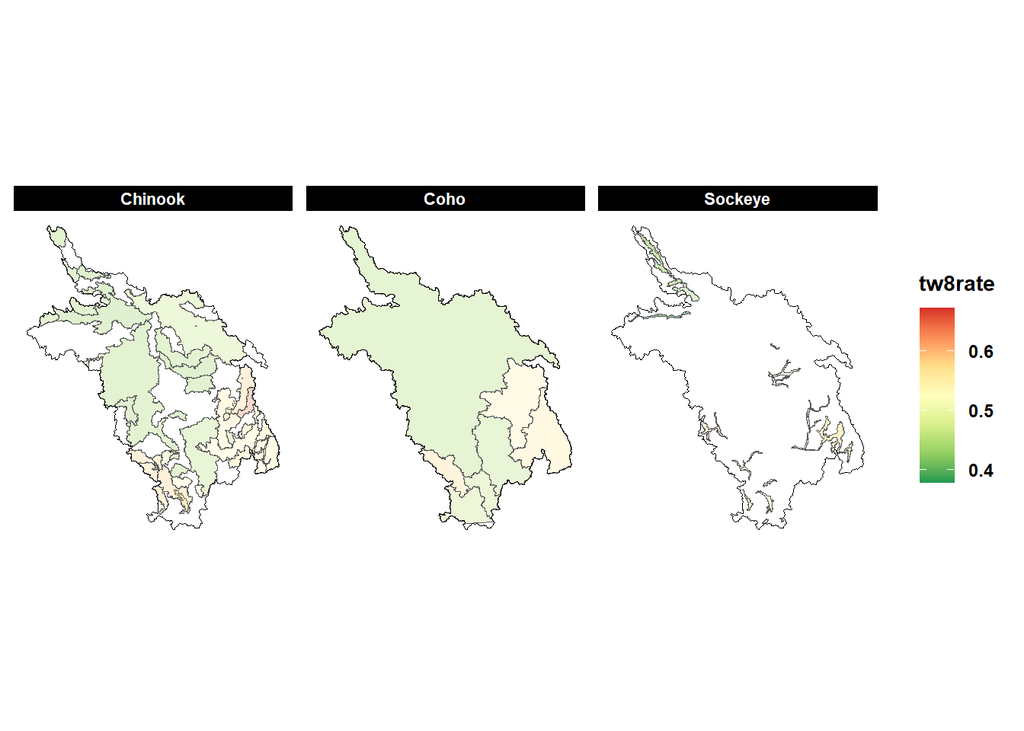

#### 85

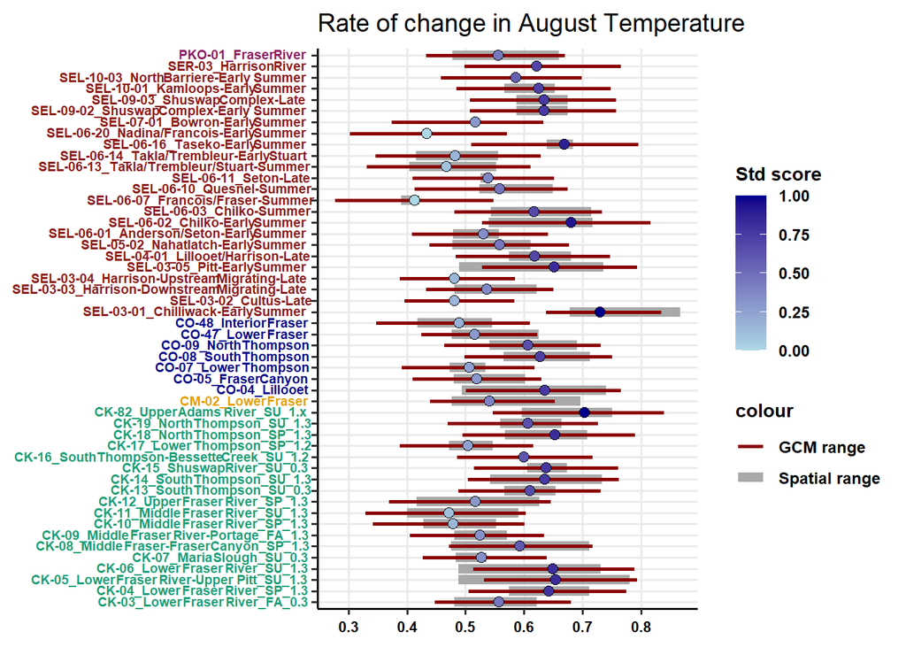

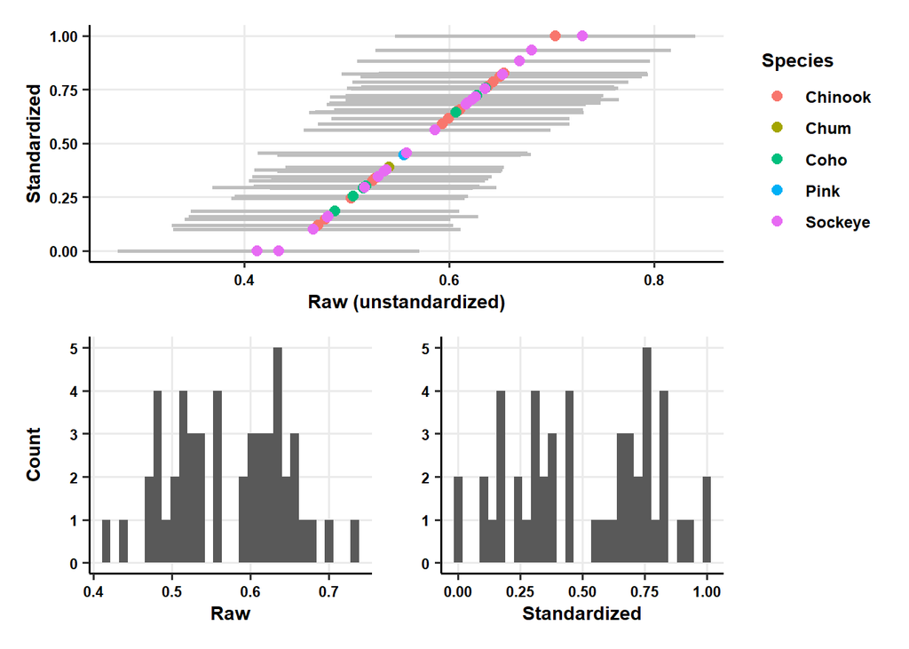

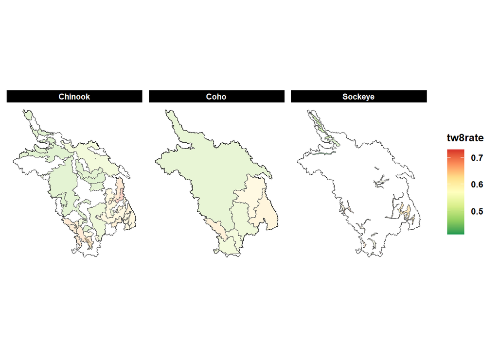

### Change in August flow (stream model)

#### 45

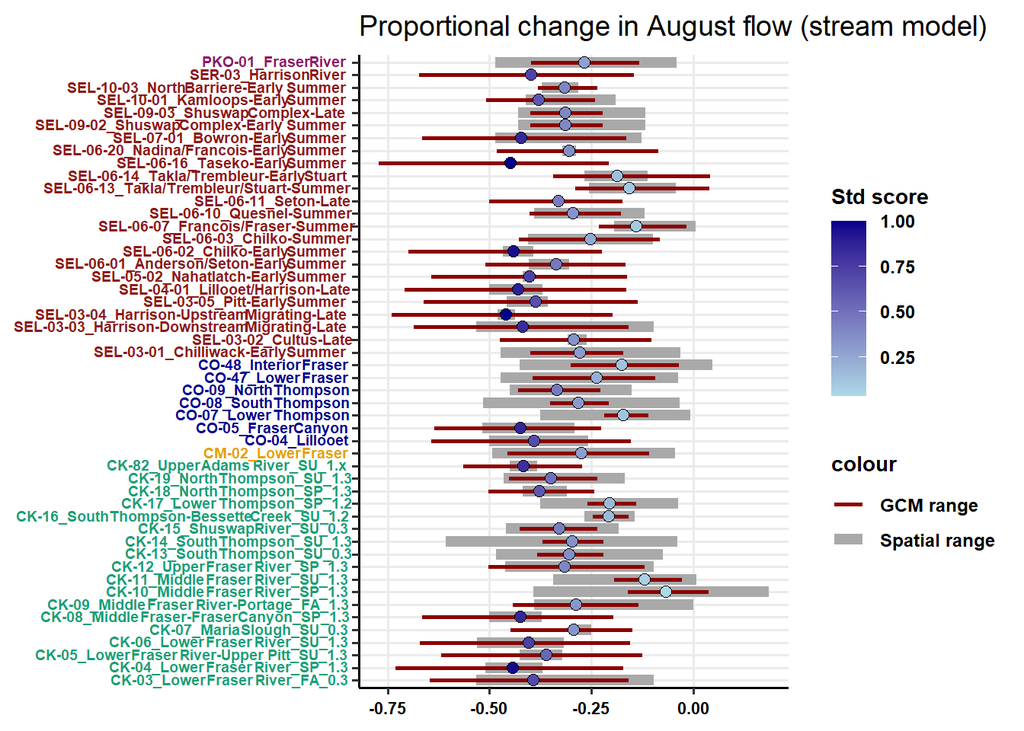

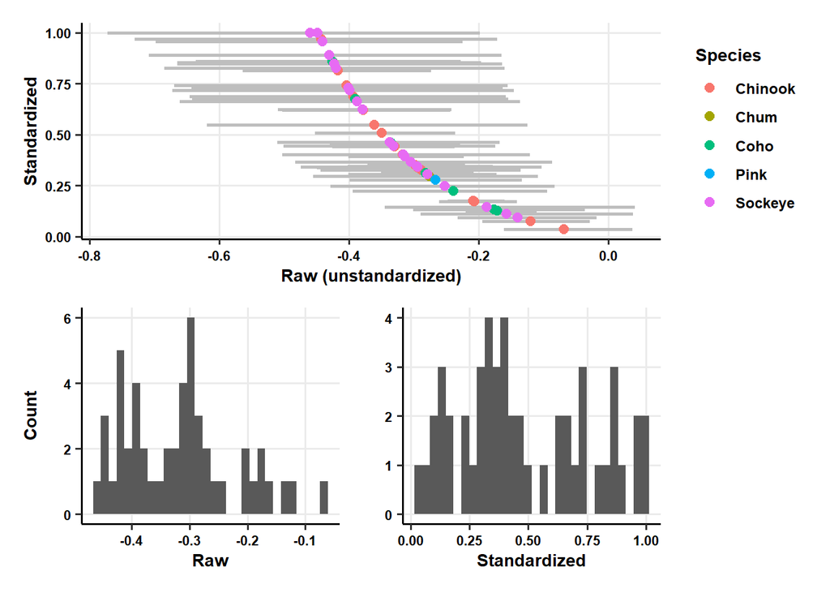

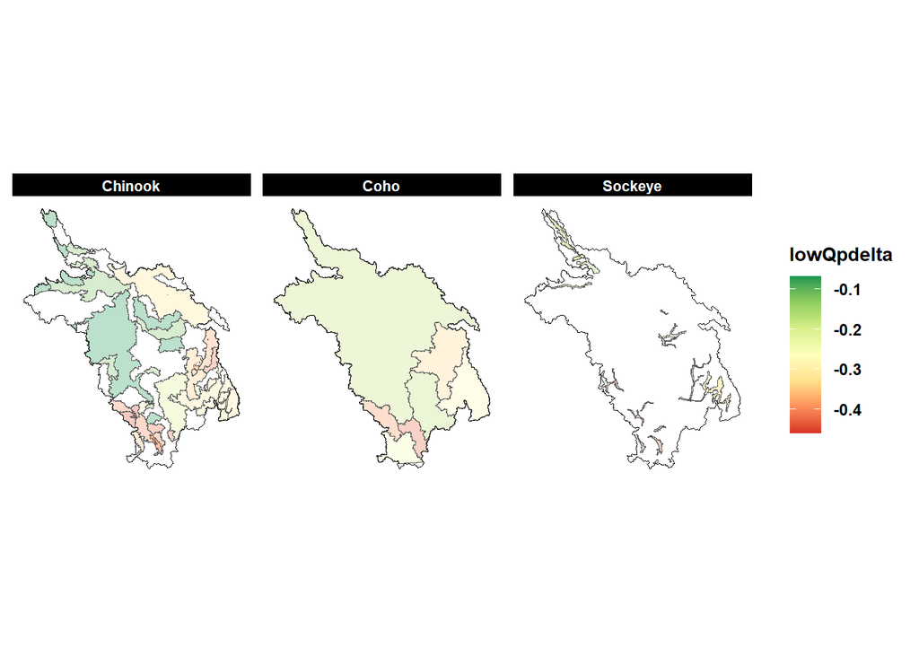

#### 85

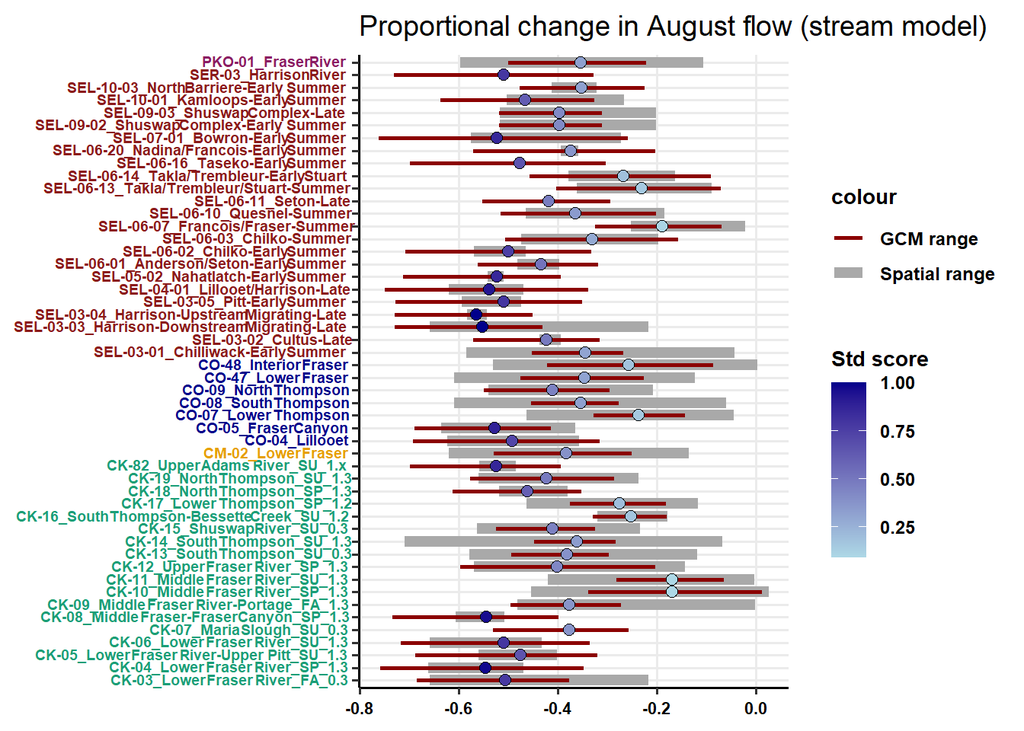

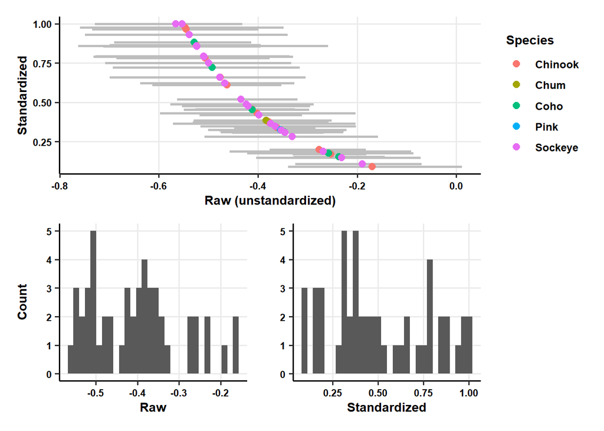

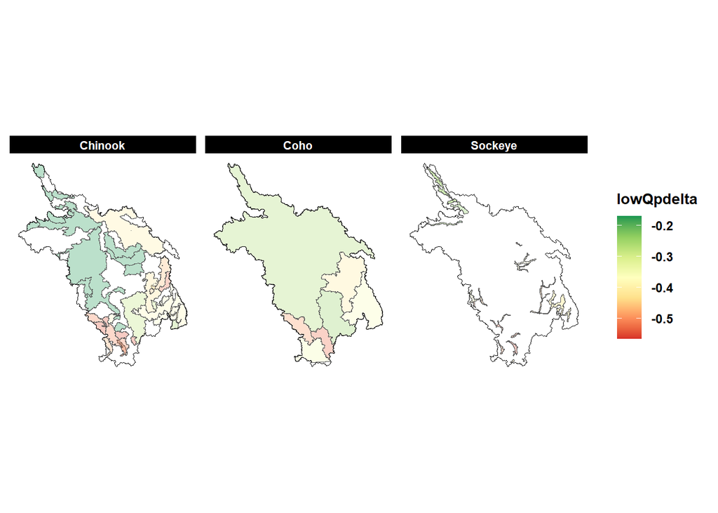